### Economy Data

```r
library(zoo) # To handle missing values
library(lubridate) # To format time data
library(xts) # To handle irregular time series data
library(forecast) # To aid seasonality detection
```

```r
library(tseries) # Test for stationarity
library(TSA) # Extended autocorrelation function plots
library(lmtest) # To detect heteroscedasticity
library(rugarch) # To incorporate GARCH model
library(ggplot2) # Fancier ACF/ PACF plots

df <- read.csv("~/hbuchholz_ma641_manuscript/upload/Economy.csv")
View(df)
summary(df)
```

```
##      Date           Excellent..            Good..       Only.fair..
##  Length:270         Length:270         Min.   : 4.00   Min.   :21.00
##  Class :character   Class :character   1st Qu.:20.00   1st Qu.:36.00
##  Mode  :character   Mode  :character   Median :28.00   Median :42.00
##                                        Mean   :28.36   Mean   :40.84
##                                        3rd Qu.:36.00   3rd Qu.:46.00
##                                        Max.   :57.00   Max.   :57.00
##      Poor..      No.Opinion..
##  Min.   : 4.00   Length:270
##  1st Qu.:15.00   Class :character
##  Median :22.00   Mode  :character
##  Mean   :25.51
##  3rd Qu.:33.00
##  Max.   :73.00
```

```r
str(df) # Include data type
```

```
## 'data.frame':    270 obs. of  6 variables:
##  $ Date        : chr  "2024 Mar 1-20" "2024 Feb 1-20" "2024 Jan 2-22" "2023 Dec 1-20" ...
##  $ Excellent.. : chr  "4" "4" "5" "3" ...
##  $ Good..      : int  26 22 22 19 17 17 17 21 20 18 ...
##  $ Only.fair.. : int  30 32 29 33 31 33 32 35 35 37 ...
##  $ Poor..      : int  39 41 45 45 50 47 48 42 42 44 ...
##  $ No.Opinion..: chr  "1" "*" "*" "*" ...
```

```r
missing_values_per_column <- colSums(is.na(df)) # Include number of missing values
print(missing_values_per_column)
```

```
##         Date  Excellent..       Good..  Only.fair..       Poor.. No.Opinion..
##            0            0            0            0            0            0
```

```r
# Pre-processing
unique(df$No.Opinion..) # Look at unique values that might not be numbers
```

```
## [1] "1"  "*"  "--" "2"
```

```r
unique(df$Excellent..) # Look at unique values that might not be numbers
```

```
##  [1] "4"  "5"  "3"  "2"  "1"  "*"  "7"  "9"  "15" "24" "22" "18" "16" "14" "13"
## [16] "11" "12" "10" "17" "8"  "6"  "19" "25" "26" "20"
```

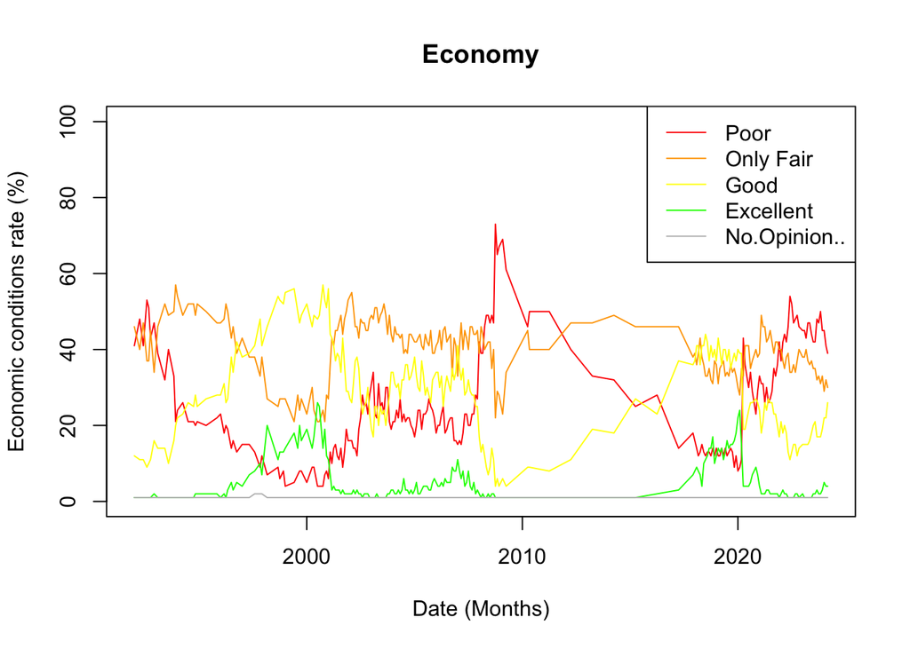

```r
df$No.Opinion..[df$No.Opinion.. %in% c("*", "--")] <- NA
df$Excellent..[df$Excellent.. %in% c("*", "--")] <- NA
df$No.Opinion.. <- na.locf(df$No.Opinion..) # Replace missing values by-last-observed-carried-forward
df$Excellent.. <- na.locf(df$Excellent..) # Replace missing values by-last-observed-carried-forward
df$No.Opinion.. <- as.numeric(df$No.Opinion..) # Format "No Opinion" field as numeric for TS analysis
df$Excellent.. <- as.numeric(df$Excellent..) # Format "Excellent" field as numeric for TS analysis
df$Date <- substring(df$Date, 1, 8) # Trim the date
df$Date <- ym(df$Date) # format the date as YYYYMM
df <- df[order(df$Date), ] # Sort data by date
df <- df[!duplicated(df$Date), ] # Remove duplicates
X <- df$Date

# TS Plots
plot(df$Poor..~X, type = "l", col = "red", ylim = c(0, 100), main = "Economy", xlab = "Date (Months)", ylab = "Economic conditions rate (%)")
lines(df$Only.fair..~X, type = "l", col = "orange")
lines(df$Good..~X, type = "l", col = "yellow")
lines(df$Excellent..~X, type = "l", col = "green")
lines(df$No.Opinion..~X, type = "l", col = "grey")
legend("topright", legend = c("Poor", "Only Fair", "Good", "Excellent", "No.Opinion.."), col = c("red", "orange", "yellow", "green", "grey"), lty = 1)
```

```r
# Irregular TS
data_xts <- xts(df$Good.., order.by = df$Date)
print(head(data_xts))
```

```
##            [,1]
## 1992-01-01   12
## 1992-04-01   11
## 1992-06-01   11
## 1992-08-01    9
## 1992-09-01   10
## 1992-10-01   11
```

```r
# Resampling to annual data using interpolation
X <- seq(start(data_xts), end(data_xts), by = "month")
data_ts <- ts(na.approx(data_xts, xout = X), frequency = 12)

summary(data_ts)
```

```
##        V1
##  Min.   : 4.00
##  1st Qu.:17.00
##  Median :26.00
##  Mean   :26.75
##  3rd Qu.:36.19
##  Max.   :57.00
```

```r
n <- length(data_ts)
print(n)
```

```
## [1] 387
```

43% of monthly time instances were missing! Similarly, this adds limitations for our model reliability despite the size of the training data.

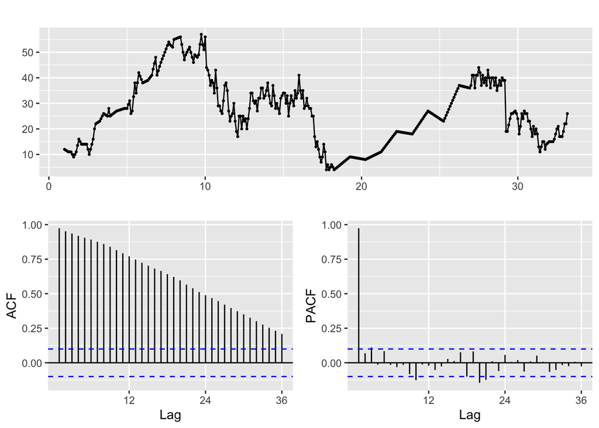

```r
# Regular and partial autocorrelation function plots
data_ts %>%
  ggtsdisplay()
```

ACF’s slow decay indicates non-stationarity of the monthly series.

```r
# Augmented Dickey-Fuller Test for stationarity
print(adf.test(data_ts, alternative = "stationary"))
```

```
##
##  Augmented Dickey-Fuller Test
##
## data:  data_ts
## Dickey-Fuller = -2.2027, Lag order = 7, p-value = 0.4916
## alternative hypothesis: stationary
```

Dickey-Fuller test’s p-value greater than 0.01 fails to reject the null hypothesis of non-stationarity so we assume the monthly series is non-stationary. We difference the series to make it stationary.

```r
# First Differencing
data_ts_diff <- diff(data_ts)

# Augmented Dickey-Fuller test on the differenced series
print(adf.test(data_ts_diff, alternative = "stationary"))
```

```
##
##  Augmented Dickey-Fuller Test
##
## data:  data_ts_diff
## Dickey-Fuller = -6.6597, Lag order = 7, p-value = 0.01
## alternative hypothesis: stationary
```

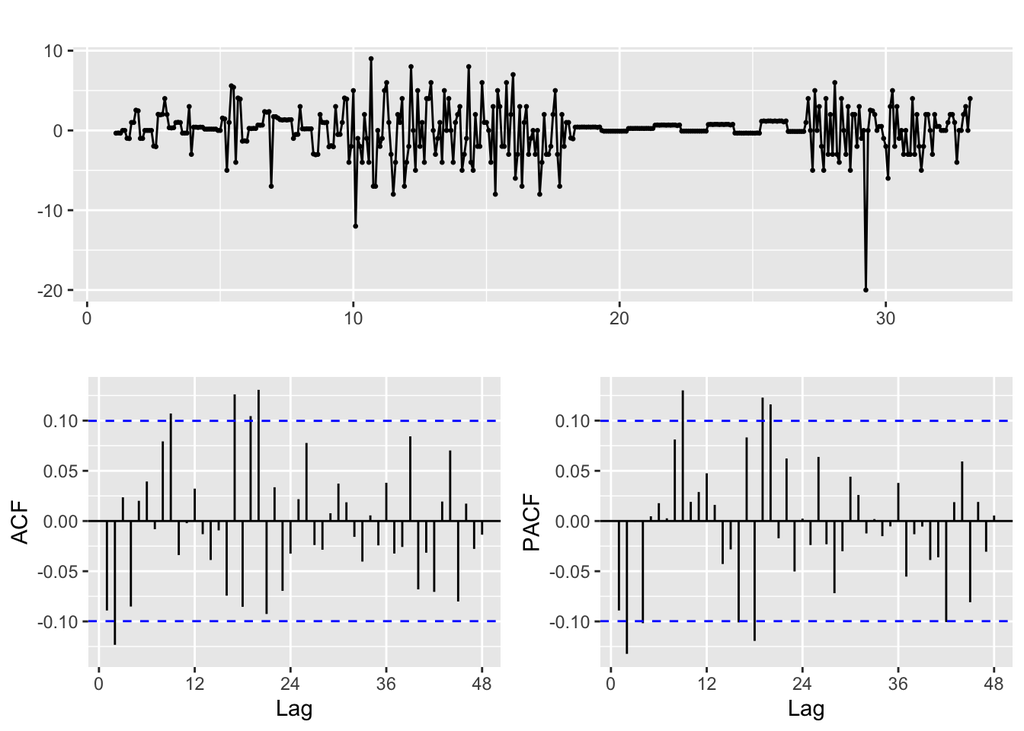

```r
data_ts_diff %>%
  ggtsdisplay(lag.max = 48)
```

The ACF and PACF plots for the differenced series look complex. None exhibit patterns of exponential decay so they are not helpful in determining the orders of our model. Then, we rely on the extended autocorrelation function (EACF).

```r
eacf(data_ts_diff)
```

```
## AR/MA
##   0 1 2 3 4 5 6 7 8 9 10 11 12 13
## 0 o x o o o o o o x o o  o  o  o
## 1 x x o o o o o o x o o  o  o  o
## 2 o x o x o o o o x o o  o  o  o
## 3 o x x x o o o o o o o  o  o  o
## 4 o x o x o o o o o o o  o  o  o
## 5 x x o x x o o o o o o  o  o  o
## 6 x x o x x o o o o o o  o  o  o
## 7 o x o o x o x o o o o  o  o  o
```

The EACF plot shows a triangle with vertex at (3, 4) and MA order no less than 2. Hence, we consider AR orders from 0 to 3 and MA orders from 2 to 4.

```r
for(p in 0: 3){
  for(q in 2: 4){
    model <- Arima(data_ts, order = c(p, 1, q), method = 'ML') # Maximum likelihood
    cat("\np =", p, "q =", q, ":\n")
    Y <- fitted(model)
    print(model)

    # Linear model
    se <- residuals(model, standardize = TRUE)
    data_lm <- data.frame(residuals = se, fitted = Y)
    model_lm <- lm(se ~ Y + I(Y^2), data = data_lm)

    # Breusch-Pagan Test
    print(bptest(model_lm))
  }
}
```

```
##
## p = 0 q = 2 :
## Series: data_ts
## ARIMA(0,1,2)
##
## Coefficients:
##           ma1      ma2
##       -0.1004  -0.1431
## s.e.   0.0511   0.0531
##
## sigma^2 = 7.878:  log likelihood = -945.11
## AIC=1896.22   AICc=1896.29   BIC=1908.09
##
##  studentized Breusch-Pagan test
##
## data:  model_lm
## BP = 11.01, df = 2, p-value = 0.004066
##
##
## p = 0 q = 3 :
## Series: data_ts
## ARIMA(0,1,3)
##
## Coefficients:
##           ma1      ma2     ma3
##       -0.1009  -0.1471  0.0169
## s.e.   0.0510   0.0541  0.0474
##
## sigma^2 = 7.896:  log likelihood = -945.05
## AIC=1898.1   AICc=1898.2   BIC=1913.92
##
##  studentized Breusch-Pagan test
##
## data:  model_lm
## BP = 10.869, df = 2, p-value = 0.004363
##
##
## p = 0 q = 4 :
## Series: data_ts
## ARIMA(0,1,4)
```

[output cut: 160 more lines]

```
## Series: data_ts
## ARIMA(3,1,4)
##
## Coefficients:
##           ar1      ar2     ar3     ma1     ma2      ma3      ma4
##       -0.6487  -0.9569  -0.128  0.5522  0.7702  -0.0365  -0.1940
## s.e.   0.2932   0.1645   0.287  0.2883  0.1467   0.2765   0.0567
##
## sigma^2 = 7.816:  log likelihood = -941.23
## AIC=1898.46   AICc=1898.84   BIC=1930.11
##
##  studentized Breusch-Pagan test
##
## data:  model_lm
## BP = 10.349, df = 2, p-value = 0.00566
```

White test’s p-values less than 0.01 for all candidates reject the null hypothesis of constant variance of the residuals so the constancy of variance assumption has been violated at 1%-significance. The current best model is ARIMA(3, 1, 3) with significantly lower AIC (1890.31).

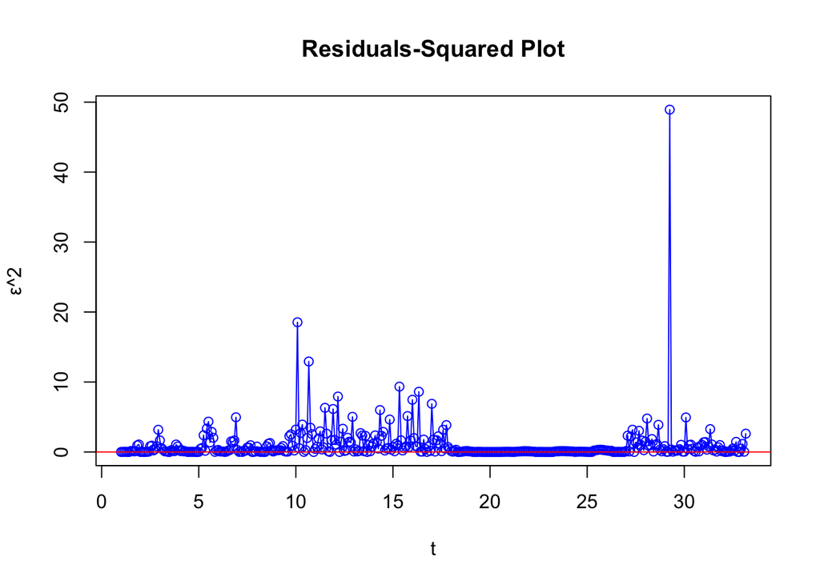

```r
model <- Arima(data_ts, order = c(3, 1, 3), method = 'ML') # Current best mean model
ε <- rstandard(model) # Standardized residuals

plot(ε^2, type = 'o', col = 'blue', main = 'Residuals-Squared Plot', xlab = "t")
    abline(h = 0, col = "red")
```

The squared standardized residuals plot exhibits volatility clusters which calls for the need of a GARCH model. We consider the auto correlations of the squared residuals, absolute returns, and squared returns to help us determine GARCH orders.

```r
# Autocorrelation of Squared Residuals and returns for GARCH parameters
Y <- fitted(model)
data_ts_return <- diff(log(data_ts)) # Returns

print("Residual-Squared:")
```

```
## [1] "Residual-Squared:"
```

```r
eacf(ε^2)
```

```
## AR/MA
##   0 1 2 3 4 5 6 7 8 9 10 11 12 13
## 0 o o o o o o x o o o o  o  o  o
## 1 x o o o o o x o o o o  o  o  o
## 2 x x o o o o x o o o o  o  o  o
## 3 x o o o o o o o o o o  o  o  o
## 4 x o o x o o o o o o o  o  o  o
## 5 x o o x o o o o o o o  o  o  o
## 6 x x x x o x o o o o o  o  o  o
## 7 x o x o x x x o o o o  o  o  o
```

```r
print("Absolute Returns:")
```

```
## [1] "Absolute Returns:"
```

```r
eacf(abs(data_ts_return))
```

```
## AR/MA
##   0 1 2 3 4 5 6 7 8 9 10 11 12 13
## 0 x x x x x x x x x x x  x  o  x
## 1 x x o o o o o o x o x  o  o  o
## 2 x o o o o o o o o o x  o  x  o
## 3 x x o o o o o o o o o  o  o  o
## 4 x o o x o o o o o o o  o  o  o
## 5 x x x x o o o o o o o  o  o  o
## 6 x x x x o o o o o o o  o  o  o
## 7 x o x x x o x o o o o  o  o  o
```

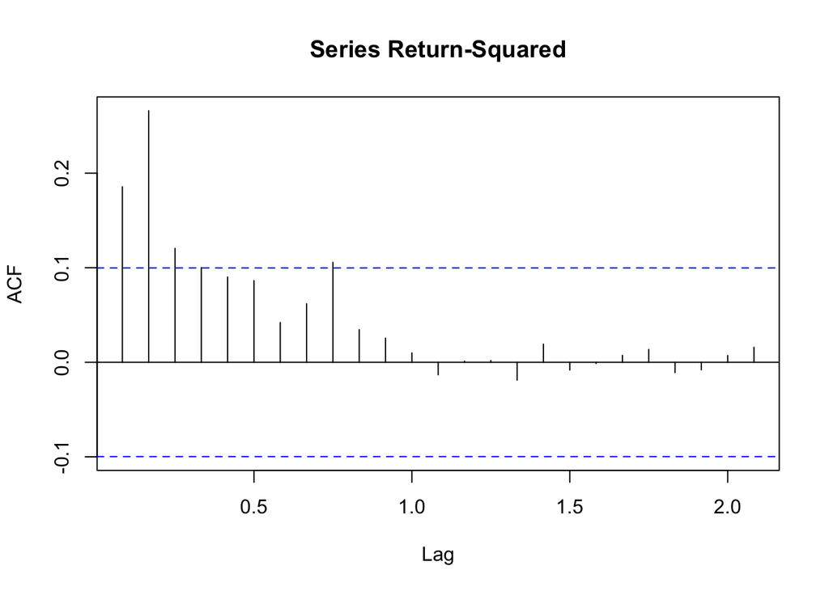

```r
acf(data_ts_return^2, main = "Series Return-Squared")
```

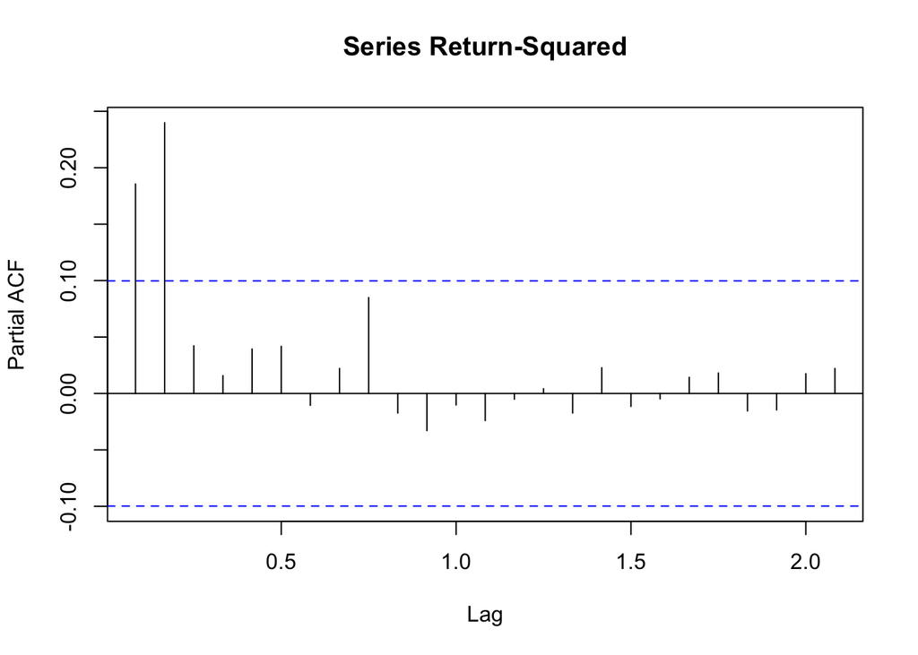

```r
pacf(data_ts_return^2, main = "Series Return-Squared")
```

Both the squared residuals and absolute returns EACF plots show a triangle with vertex at (3, 3). For the the squared returns, the ACF plot tails off and the PACF plot shows 2 significant lags suggesting GARCH orders qg = 0 and pg = 2.

```r
for(p in 0: 3){
  for(q in 0: 3){
    model_garch <- ugarchspec(variance.model = list(model = "sGARCH",
                                                    garchOrder = c(p, q), submodel = NULL,
                                                    external.regressors = NULL,
                                                    variance.targeting = FALSE),

                              mean.model = list(armaOrder = c(3, 3),
                                                external.regressors = NULL,
                                                include.mean = FALSE
                                                ),

                              distribution.model = "norm") # Stationary differenced series presumes uncorrelated returns with zero mean/ no constant term

    GARCH_fit <- ugarchfit(spec = model_garch, data = data_ts_return)
    print(GARCH_fit)
  }
}
```

```
##
## *---------------------------------*
## *          GARCH Model Fit        *
## *---------------------------------*
##
## Conditional Variance Dynamics
## -----------------------------------
## GARCH Model  : sGARCH(0,0)
## Mean Model   : ARFIMA(3,0,3)
## Distribution : norm
##
## Convergence Problem:
## Solver Message:
##
##
## *---------------------------------*
## *          GARCH Model Fit        *
## *---------------------------------*
##
## Conditional Variance Dynamics
## -----------------------------------
## GARCH Model  : sGARCH(0,1)
## Mean Model   : ARFIMA(3,0,3)
## Distribution : norm
##
## Optimal Parameters
## ------------------------------------
##        Estimate  Std. Error    t value Pr(>|t|)
## ar1    1.362320    0.117790   11.56564 0.000000
## ar2   -0.545159    0.231205   -2.35791 0.018378
## ar3    0.017768    0.165094    0.10762 0.914294
## ma1   -1.454569    0.105941  -13.73002 0.000000
## ma2    0.508433    0.181759    2.79730 0.005153
## ma3    0.116011    0.155038    0.74828 0.454293
## omega  0.000054    0.000010    5.19843 0.000000
## beta1  0.996723    0.000707 1409.80794 0.000000
##
## Robust Standard Errors:
##        Estimate  Std. Error    t value Pr(>|t|)
## ar1    1.362320    0.300505    4.53343 0.000006
```

[output cut: 282 more lines]

```
## Negative Sign Bias  3.4255 0.0006804 ***
## Positive Sign Bias  2.3940 0.0171492  **
## Joint Effect       17.7531 0.0004945 ***
##
##
## Adjusted Pearson Goodness-of-Fit Test:
## ------------------------------------
##   group statistic p-value(g-1)
## 1    20     115.0    9.330e-16
## 2    30     126.0    4.634e-14
## 3    40     130.1    9.980e-12
## 4    50     140.9    7.842e-11
##
##
## Elapsed time : 0.3554051
```

```
##
## *---------------------------------*
## *          GARCH Model Fit        *
## *---------------------------------*
##
## Conditional Variance Dynamics
## -----------------------------------
## GARCH Model  : sGARCH(1,0)
## Mean Model   : ARFIMA(3,0,3)
## Distribution : norm
##
## Convergence Problem:
## Solver Message:
##
##
## *---------------------------------*
## *          GARCH Model Fit        *
## *---------------------------------*
##
## Conditional Variance Dynamics
## -----------------------------------
## GARCH Model  : sGARCH(1,1)
## Mean Model   : ARFIMA(3,0,3)
## Distribution : norm
##
## Optimal Parameters
## ------------------------------------
##         Estimate  Std. Error   t value Pr(>|t|)
## ar1     1.989314    0.008567  232.1967 0.000000
## ar2    -1.309804    0.003276 -399.7580 0.000000
## ar3     0.239411    0.037885    6.3194 0.000000
## ma1    -1.633985    0.024570  -66.5040 0.000000
## ma2     0.720537    0.029971   24.0414 0.000000
## ma3     0.096652    0.021949    4.4035 0.000011
## omega   0.000066    0.000023    2.8766 0.004019
## alpha1  0.237991    0.027012    8.8107 0.000000
## beta1   0.761009    0.022348   34.0533 0.000000
##
## Robust Standard Errors:
##         Estimate  Std. Error  t value Pr(>|t|)
```

[output cut: 1203 more lines]

```
## Negative Sign Bias  0.2896 0.7723
## Positive Sign Bias  0.1578 0.8747
## Joint Effect        0.3515 0.9501
##
##
## Adjusted Pearson Goodness-of-Fit Test:
## ------------------------------------
##   group statistic p-value(g-1)
## 1    20     57.21    1.059e-05
## 2    30     68.97    4.184e-05
## 3    40     85.30    2.652e-05
## 4    50     89.91    3.306e-04
##
##
## Elapsed time : 0.209851
```

We compare the models with standard parameters in terms of AIC, Weighted Ljung-Box test results which indicate uncorrelated residuals (aim of GARCH modeling), and Adjusted Pearson Goodness-of-Fit test results. Some 0-order models did not even converge. The model that best weights these three criteria is ARIMA(3, 1, 3)-GARCH(3, 2) with AIC = -1.9302, Weighted Ljung-Box Test on Standardized Residuals p-value > 0.01 and Adjusted Pearson Goodness-of-Fit Test passing for 2/ 4 groups. We further run model diagnostics.

```
##
## please wait...calculating quantiles...
```

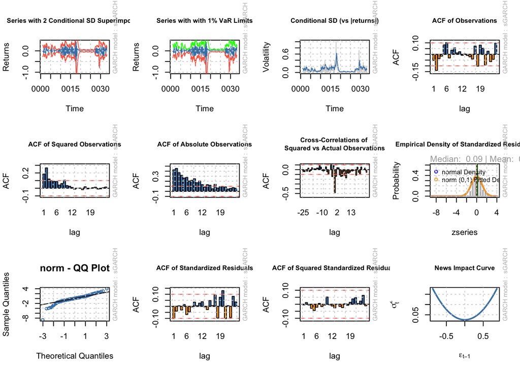

```r
# Model Diagnosis
model_garch <- ugarchspec(variance.model = list(model = "sGARCH",
                                                    garchOrder = c(3, 2), submodel = NULL,
                                                    external.regressors = NULL,
                                                    variance.targeting = FALSE),

                              mean.model = list(armaOrder = c(3, 3),
                                                external.regressors = NULL,
                                                include.mean = FALSE
                                                ),
                          distribution.model = "norm"
                          )

GARCH_fit <- ugarchfit(spec = model_garch, data = data_ts_return)

plot(GARCH_fit, which = 'all')
```

```r
# Linear model on Squared Std. GARCH Residuals
e <- GARCH_fit@fit$residuals # ARIMA-GARCH residuals
X_lm <- 1: length(e)
data_lm <- data.frame(squared_residuals = e^2, time_index = X_lm)
model_lm <- lm(e^2 ~ X_lm, data = data_lm)

# Breusch-Pagan Test
print(bptest(model_lm))
```

```
##
##  studentized Breusch-Pagan test
##
## data:  model_lm
## BP = 0.34397, df = 1, p-value = 0.5575
```

White test’s p-value > 0.01 now fails to reject the null hypothesis of constant variance of the residuals so the constancy of variance assumption has been satisfied by incorporating GARCH.

```r
# Normality Test
e_ts <- ts(e, frequency = 12) # Series Residual
shapiro.test(e_ts)
```

```
##
##  Shapiro-Wilk normality test
##
## data:  e_ts
## W = 0.86233, p-value < 2.2e-16
```

Shapiro Wilk test’s p-value much smaller than 0.01 rejects the null hypothesis of normally distributed residuals so the normality assumption is violated (limitation).

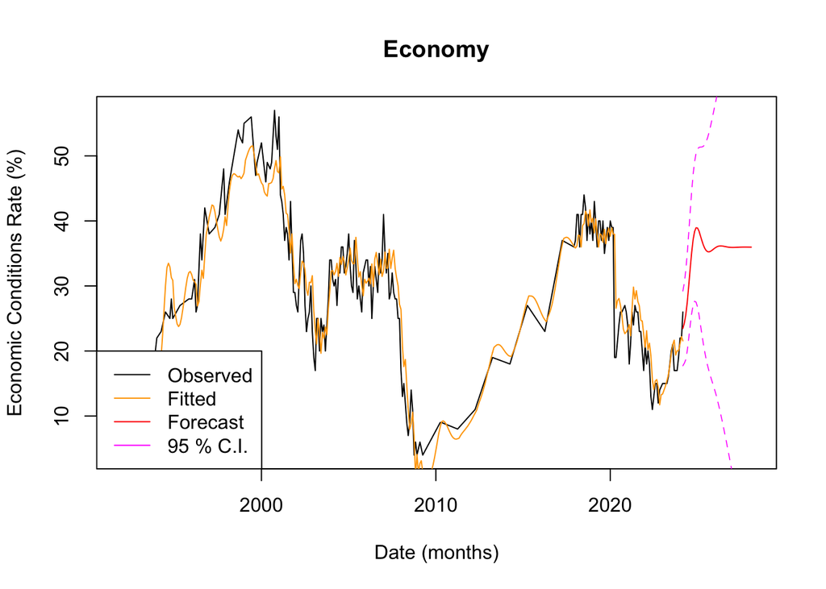

```r
# Forecasts

R <- fitted(GARCH_fit) # Fitted returns
model_garch_h = ugarchforecast(fitORspec = GARCH_fit, n.ahead = 48) # Four years into the future
R_h <- fitted(model_garch_h) # Return forecast
H <- seq(from = end(data_xts), length.out = 48, by = "month")
V <- GARCH_fit@fit$sigma^2 # Fitted volatility
V_h <- sigma(model_garch_h)^2 # Volatility forecast

Y_h_first = 16 # Initial estimate
C <- data_ts[1] * exp(cumsum(R)) # Fitted cumulative levels
C_h <- Y_h_first * exp(cumsum(R_h)) # Cumulative level forecasts
VC_h <- Y_h_first / 2 * exp(cumsum(V_h)) # Cumulative Volatility forecast

# Scaling factor
Y_lm <- lm(data_ts[-1] ~ C)
Y <- coef(Y_lm)[2] * C + coef(Y_lm)[1]
Y_h <- coef(Y_lm)[2] * C_h + coef(Y_lm)[1]
W_h <- coef(Y_lm)[2] * VC_h + coef(Y_lm)[1]

# 85% CI
u <- Y_h + 1.96 * W_h
l <- Y_h - 1.96 * W_h

plot(X, data_ts, type = 'l', main = "Economy", xlab = "Date (months)", ylab = "Economic Conditions Rate (%)", xlim = range(c(X, H)))
lines(X[-1], Y, col = "orange")
lines(H, Y_h, col = "red")
matlines(H, cbind(l, u), col = "magenta", lty = 2, lwd = 0.8)
legend("bottomleft", legend = c("Observed", "Fitted", "Forecast", "95 % C.I."), col = c("black", "orange", "red", "magenta"), lty = 1)
```

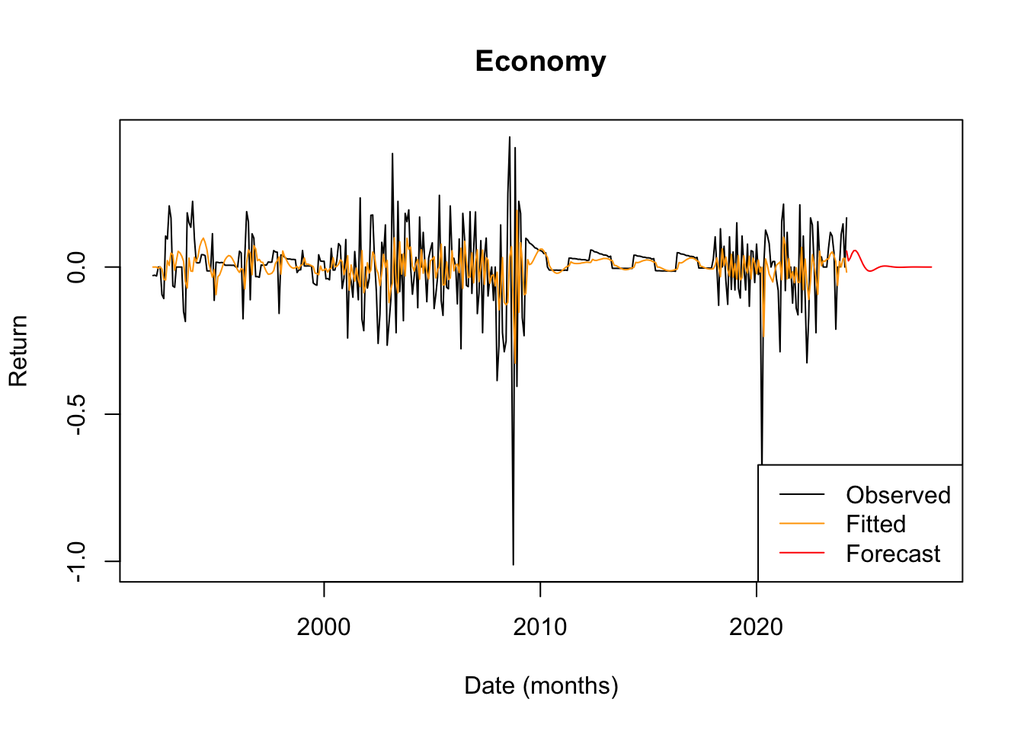

```r
plot(X[-1], data_ts_return, type = 'l', main = "Economy", xlab = "Date (months)", ylab = "Return", xlim = range(c(X, H)))
lines(H, R_h, col = "red")
lines(X[-1], R, col = "orange")
legend("bottomright", legend = c("Observed", "Fitted", "Forecast"), col = c("black", "orange", "red"), lty = 1)
```

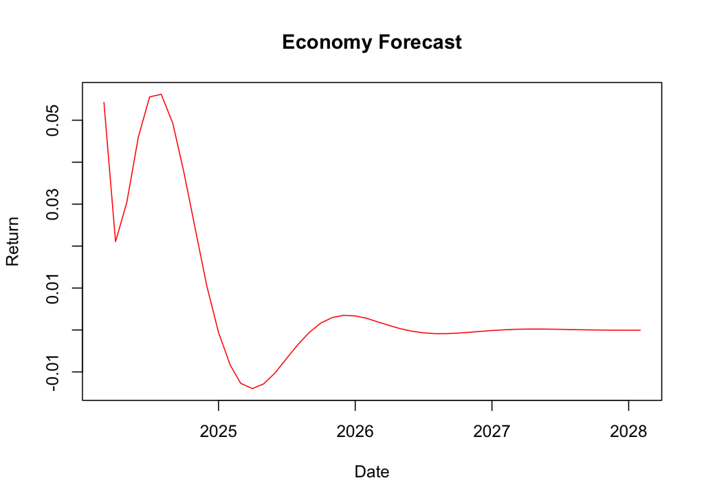

```r
plot(H, R_h, type = 'l', main = "Economy Forecast", xlab = "Date", ylab = "Return", col = "red")
```

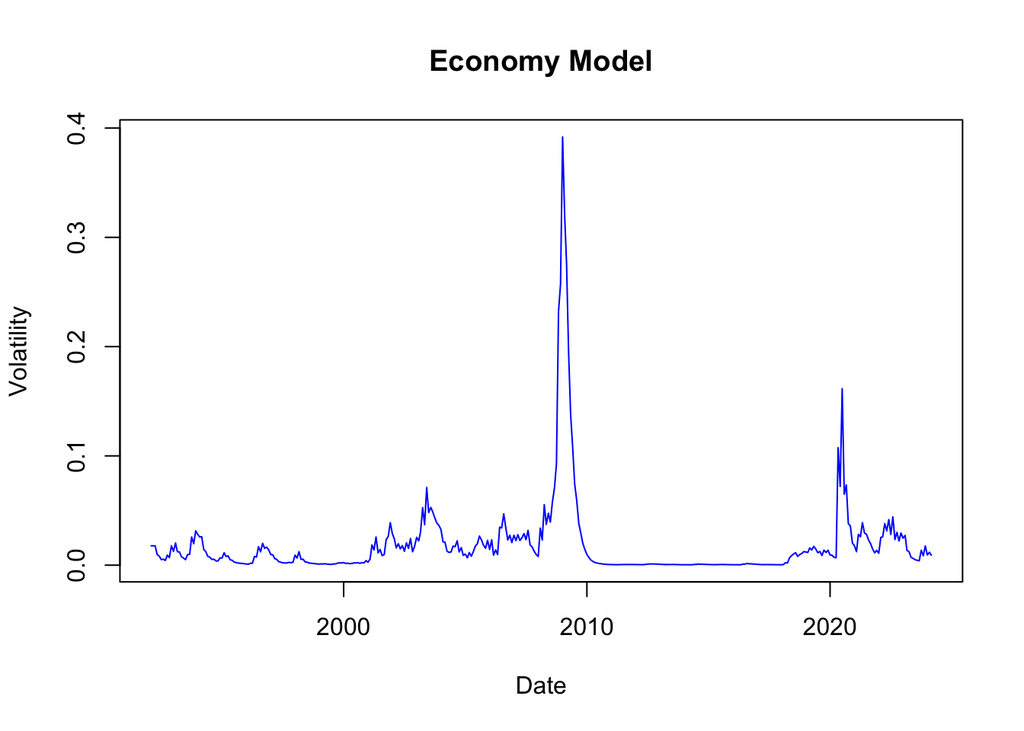

```r
plot(X[-1], V, type = 'l', main = "Economy Model", xlab = "Date", ylab = "Volatility", col = "blue")
```

### Conclusions

The missing months still coaxed us into underestimating the variability of our data which might have misled our conclusions. More robust methods (e.g. K-nearest neighbors (KNN) or Expectation Maximization (EM)) are part of our future studies to handle the missing values if collecting more data becomes impossible. On the other hand, the residuals were found to be not normally distributed which could potentially lead to incorrect inferences about our model parameters and specification. Future directions include employing different model distributions such as t-distribution especially to improve the goodness of fit for the GARCH model, removing potential outliers, and applying transformations such as Box-Cox to try to make the distribution more normal. We hope that our study provides insight on factors that may improve the satisfaction with the U.S.

### References

Gallup, Inc. (n.d.). Gallup poll topics and complete trends, including presidential job approval, elections, business, institutions, social issues, religion and more. https://news.gallup.com/poll/trends.aspx

[2]: Gallup. (2022a, October 27). Satisfaction with the United States. Gallup.com. https://news.gallup.com/poll/1669/General-Mood-Country.aspx

Case study of bitcoin historical and S&P 500 stock datasets. (n.d.-a). https://www.researchgate.net/publication/361755725\Seasonal\and\\\Nonseasonal\GARCH\Time\Series\Analysis\Case\Study\of\Bitcoin\\\Historical\and\SP\500\stock\datasets

Applying arima-GARCH models for time series analysis … (n.d.-a). https://www.researchgate.net/publication/361623092\Applying\ARIMA-GARCH\models\for\time\series\analysis\on\Seasonal\and\Nonseasonal\\\datasets

[^1]: Gallup. (2022, October 31). Economy. Gallup.com. https://news.gallup.com/poll/1609/consumer-views-economy.aspx